# Technical Appendix

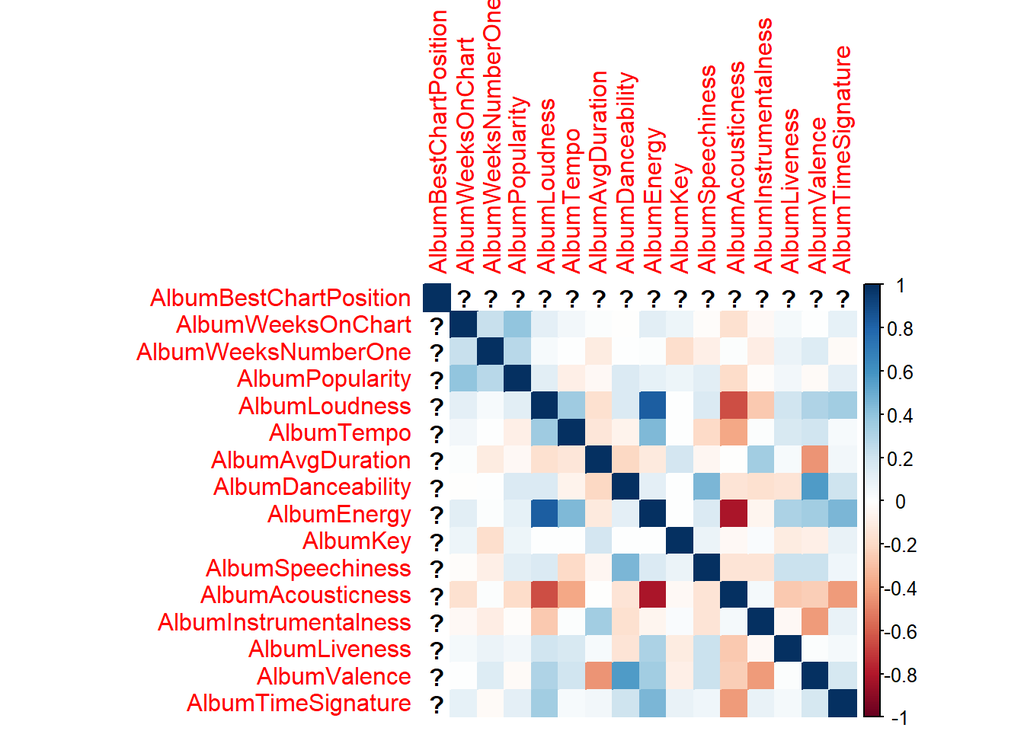

```r
corrplot(correlations, method = "color")
```

##On genre Only 4 metal songs, only 7 jazz songs

```r
analysis <- function(myData)
{
    print(mean(myData$AlbumPopularity))
    corData <- select(ungroup(myData), -ArtistNumFollowers, -ArtistPopularity, -Release_year, -Release_month, -Season, -isPop, -isRock, -isIndie, -isFolk, -isMetal, -isTechno, -isBlues, -isRap, -isPunk,-isJazz)
    correlations <- cor(corData)
    corrplot(correlations, method = "color")
}

rap <- filter(myData, isRap == TRUE)
cor(rap$AlbumPopularity, rap$AlbumAcousticness)
```

```
## [1] 0.3297751
```

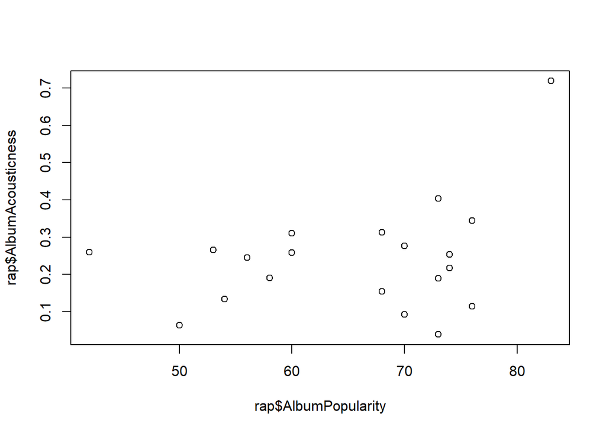

```r
plot(rap$AlbumPopularity, rap$AlbumAcousticness)
```

```r
pop <- filter(myData, isPop == TRUE)
indie <- filter(myData, isIndie == TRUE)
folk <- filter(myData, isFolk == TRUE)
metal <- filter(myData, isMetal == TRUE)
techno <- filter(myData, isTechno == TRUE)
jazz <- filter(myData, isJazz == TRUE)
blues <- filter(myData, isBlues == TRUE)
punk <- filter(myData, isPunk == TRUE)
rock <- filter(myData, isRock == TRUE)

print("rap")
```

```
## [1] "rap"
```

```r
analysis(rap)
```

```
## [1] 65.55
```

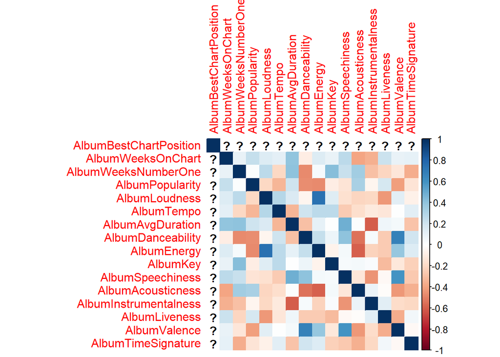

```r
print("rock")
```

```
## [1] "rock"
```

```r
analysis(rock)
```

```
## [1] 55.89552
```

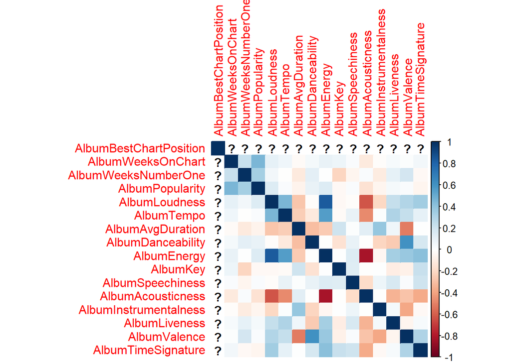

```r
print("Indie")
```

```
## [1] "Indie"
```

```r
analysis(indie)
```

```
## [1] 58.74419
```

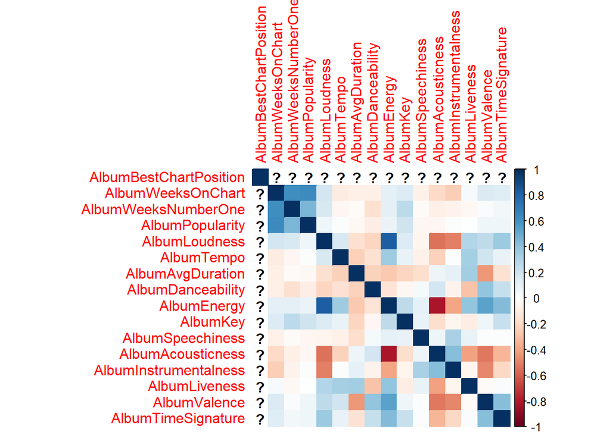

```r
print("techno")
```

```
## [1] "techno"
```

```r
analysis(techno)
```

```
## [1] 56.73077
```

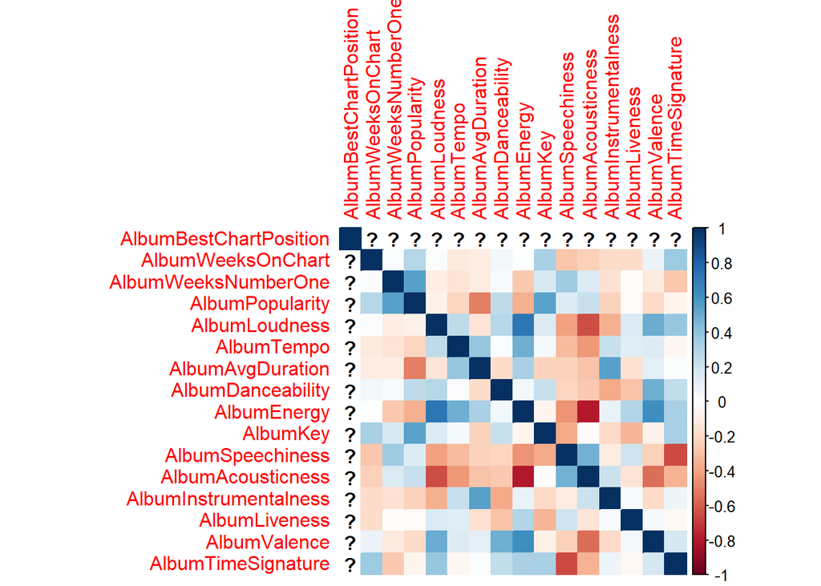

```r
print("pop")
```

```
## [1] "pop"
```

```r
analysis(pop)
```

```
## [1] 53.69159
```

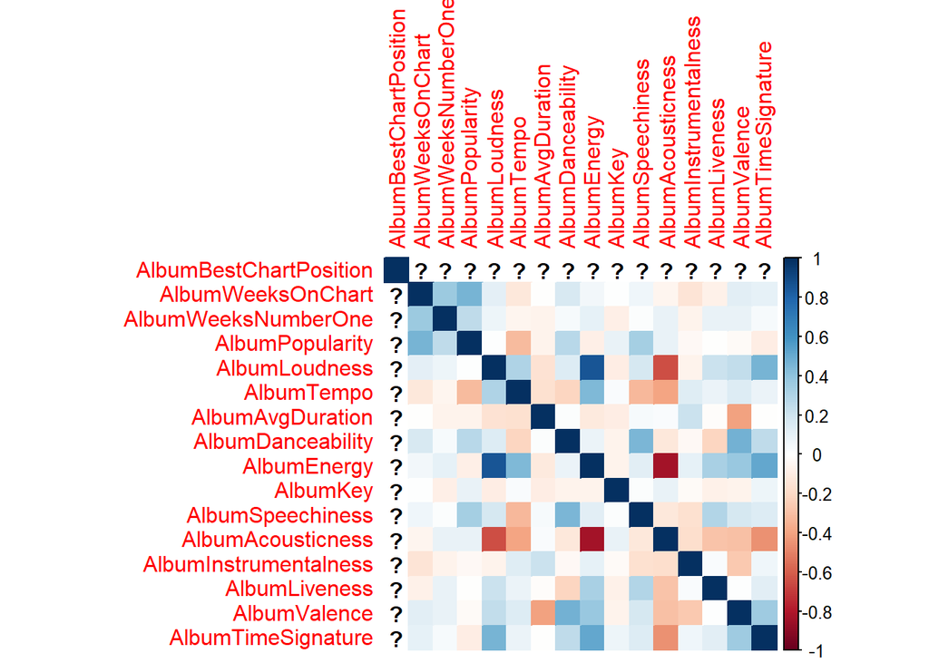

```r
print("folk")
```

```
## [1] "folk"
```

```r
analysis(folk)
```

```
## [1] 50.4
```

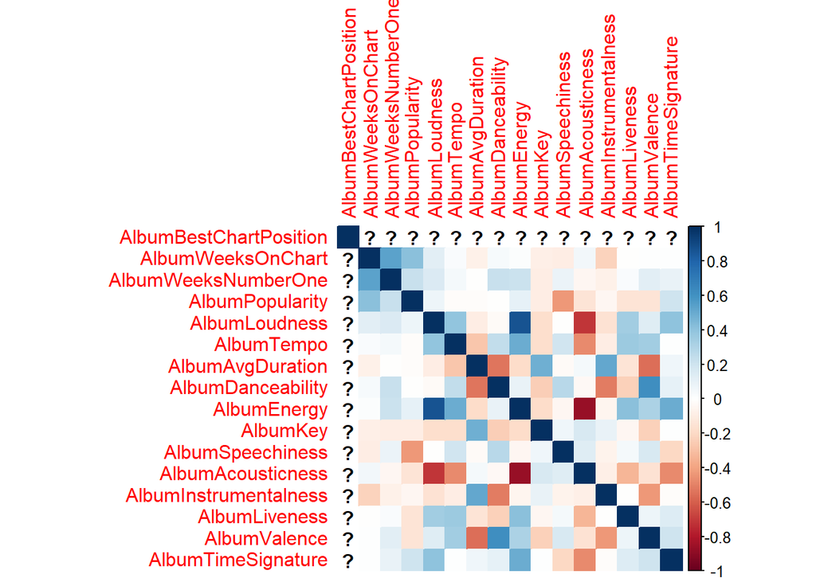

```r
print("jazz")
```

```
## [1] "jazz"
```

```r
analysis(jazz)
```

```
## [1] 41.28571
```

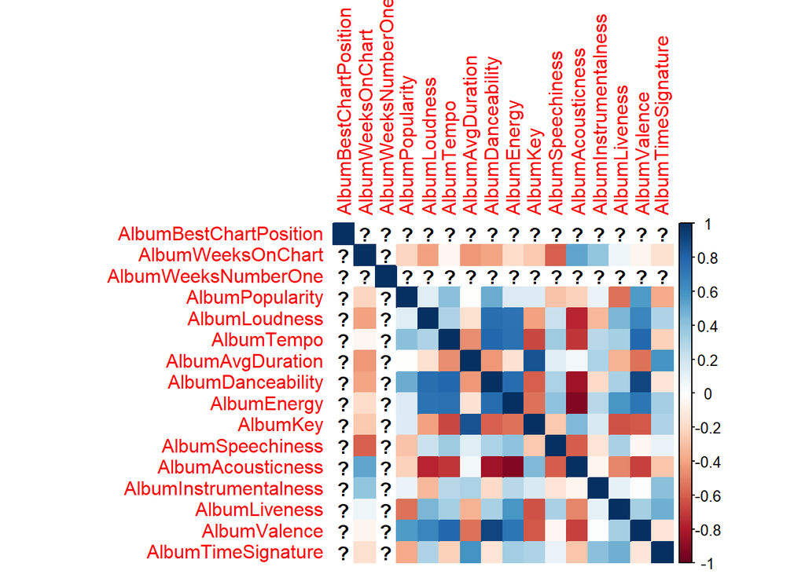

```r
print("blues")
```

```
## [1] "blues"
```

```r
analysis(blues)
```

```
## [1] 60.90476
```

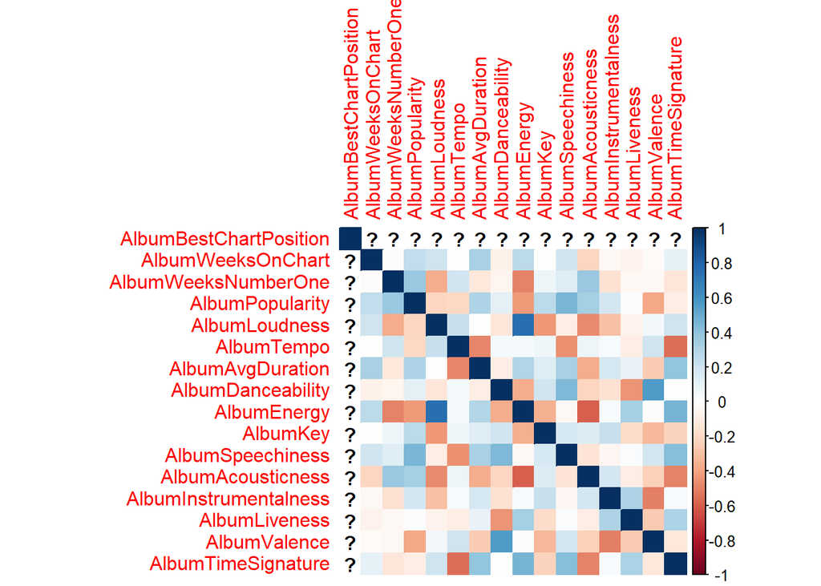

```r
print("punk")
```

```
## [1] "punk"
```

```r
analysis(punk)
```

```
## [1] 48.32
```

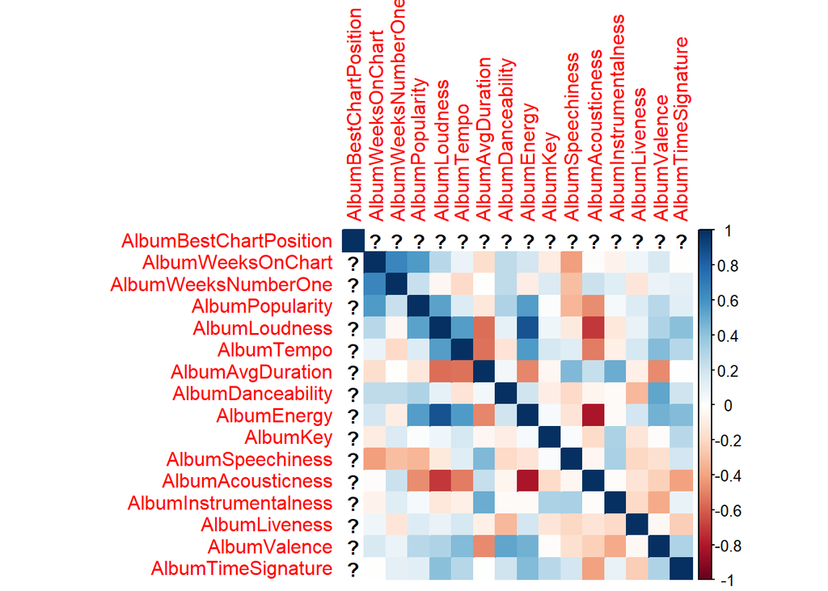

```r
#tempo
model1 <- glm(AlbumPopularity ~ AlbumDanceability + AlbumLoudness + AlbumSpeechiness + AlbumEnergy + AlbumAcousticness,data = myData, family = quasi(link = "log", variance = "mu^2"))
summary(model1)
```

```
##
## Call:
## glm(formula = AlbumPopularity ~ AlbumDanceability + AlbumLoudness +
##     AlbumSpeechiness + AlbumEnergy + AlbumAcousticness, family = quasi(link = "log",
##     variance = "mu^2"), data = myData)
##
## Deviance Residuals:
##      Min        1Q    Median        3Q       Max
## -2.38572  -0.19432   0.01961   0.21677   0.64610
##
## Coefficients:
##                   Estimate Std. Error t value Pr(>|t|)
## (Intercept)        4.33612    0.29257  14.821   <2e-16 ***
## AlbumDanceability  0.24674    0.18991   1.299   0.1953
## AlbumLoudness      0.01018    0.01006   1.012   0.3127
## AlbumSpeechiness   0.16470    0.34738   0.474   0.6359
## AlbumEnergy       -0.41225    0.27626  -1.492   0.1372
## AlbumAcousticness -0.36646    0.14850  -2.468   0.0144 *
## ---
## Signif. codes:  0 '***' 0.001 '**' 0.01 '*' 0.05 '.' 0.1 ' ' 1
##
## (Dispersion parameter for quasi family taken to be 0.09160589)
##
##     Null deviance: 29.749  on 209  degrees of freedom
## Residual deviance: 28.497  on 204  degrees of freedom
## AIC: NA
##
## Number of Fisher Scoring iterations: 5
```

```r
anova(model1, test= "Chi")
```

```
## Analysis of Deviance Table
##
## Model: quasi, link: log
##
## Response: AlbumPopularity
##
## Terms added sequentially (first to last)
##
##
##                   Df Deviance Resid. Df Resid. Dev Pr(>Chi)
## NULL                                209     29.748
## AlbumDanceability  1  0.45238       208     29.296  0.02627 *
## AlbumLoudness      1  0.22390       207     29.072  0.11796
## AlbumSpeechiness   1  0.02921       206     29.043  0.57232
## AlbumEnergy        1  0.00255       205     29.041  0.86752
## AlbumAcousticness  1  0.54326       204     28.497  0.01488 *
## ---
## Signif. codes:  0 '***' 0.001 '**' 0.01 '*' 0.05 '.' 0.1 ' ' 1
```

```r
print("GAPHERE")
```

```
## [1] "GAPHERE"
```

```r
model2 <- lm((AlbumPopularity) ~ AlbumDanceability + AlbumAcousticness,data = myData)
summary(model2)
```

```
##
## Call:
## lm(formula = (AlbumPopularity) ~ AlbumDanceability + AlbumAcousticness,
##     data = myData)
##
## Residuals:
##     Min      1Q  Median      3Q     Max
## -49.023 -10.806   1.519  13.329  45.010
##
## Coefficients:
##                   Estimate Std. Error t value Pr(>|t|)
## (Intercept)         50.546      5.469   9.242   <2e-16 ***
## AlbumDanceability   17.152      9.225   1.859   0.0644 .
## AlbumAcousticness  -11.524      4.649  -2.479   0.0140 *
## ---
## Signif. codes:  0 '***' 0.001 '**' 0.01 '*' 0.05 '.' 0.1 ' ' 1
##
## Residual standard error: 16.48 on 207 degrees of freedom
## Multiple R-squared:  0.05103,    Adjusted R-squared:  0.04186
## F-statistic: 5.566 on 2 and 207 DF,  p-value: 0.004422
```

```r
anova(model2, test= "Chi")
```

```
## Analysis of Variance Table
##
## Response: (AlbumPopularity)
##                    Df Sum Sq Mean Sq F value  Pr(>F)
## AlbumDanceability   1   1354 1353.81  4.9871 0.02661 *
## AlbumAcousticness   1   1668 1667.88  6.1441 0.01398 *
## Residuals         207  56193  271.46
## ---
## Signif. codes:  0 '***' 0.001 '**' 0.01 '*' 0.05 '.' 0.1 ' ' 1
```

```r
musicalData1 <- select(ungroup(myData), -ArtistNumFollowers, -ArtistPopularity, -Release_year, -Release_month, -Season, -isPop, -isRock, -isIndie, -isFolk, -isMetal, -isTechno, -isBlues, -isRap, -isPunk,-isJazz, -AlbumBestChartPosition,  -AlbumWeeksOnChart, -AlbumWeeksNumberOne)
models<-regsubsets(AlbumPopularity~. ,musicalData, nvmax = 8 )
summary(models)
```

```
## Subset selection object
## Call: regsubsets.formula(AlbumPopularity ~ ., musicalData, nvmax = 8)
## 15 Variables  (and intercept)
##                        Forced in Forced out
## AlbumBestChartPosition     FALSE      FALSE
## AlbumWeeksOnChart          FALSE      FALSE
## AlbumWeeksNumberOne        FALSE      FALSE
## AlbumLoudness              FALSE      FALSE
## AlbumTempo                 FALSE      FALSE
## AlbumAvgDuration           FALSE      FALSE
## AlbumDanceability          FALSE      FALSE
## AlbumEnergy                FALSE      FALSE
## AlbumKey                   FALSE      FALSE
## AlbumSpeechiness           FALSE      FALSE
## AlbumAcousticness          FALSE      FALSE
## AlbumInstrumentalness      FALSE      FALSE
## AlbumLiveness              FALSE      FALSE
## AlbumValence               FALSE      FALSE
## AlbumTimeSignature         FALSE      FALSE
## 1 subsets of each size up to 8
## Selection Algorithm: exhaustive
##          AlbumBestChartPosition AlbumWeeksOnChart AlbumWeeksNumberOne
## 1  ( 1 ) " "                    "*"               " "
## 2  ( 1 ) " "                    "*"               "*"
## 3  ( 1 ) " "                    "*"               "*"
## 4  ( 1 ) "*"                    "*"               "*"
## 5  ( 1 ) "*"                    "*"               "*"
## 6  ( 1 ) "*"                    "*"               "*"
## 7  ( 1 ) "*"                    "*"               "*"
## 8  ( 1 ) "*"                    "*"               "*"
##          AlbumLoudness AlbumTempo AlbumAvgDuration AlbumDanceability
## 1  ( 1 ) " "           " "        " "              " "
## 2  ( 1 ) " "           " "        " "              " "
## 3  ( 1 ) " "           " "        " "              " "
## 4  ( 1 ) " "           " "        " "              " "
## 5  ( 1 ) " "           " "        " "              "*"
## 6  ( 1 ) " "           " "        " "              "*"
## 7  ( 1 ) " "           " "        " "              "*"
## 8  ( 1 ) " "           " "        "*"              "*"
##          AlbumEnergy AlbumKey AlbumSpeechiness AlbumAcousticness
## 1  ( 1 ) " "         " "      " "              " "
## 2  ( 1 ) " "         " "      " "              " "
## 3  ( 1 ) " "         " "      "*"              " "
## 4  ( 1 ) " "         " "      "*"              " "
## 5  ( 1 ) " "         " "      " "              " "
## 6  ( 1 ) " "         " "      "*"              " "
## 7  ( 1 ) " "         " "      "*"              "*"
## 8  ( 1 ) " "         " "      "*"              "*"
##          AlbumInstrumentalness AlbumLiveness AlbumValence AlbumTimeSignature
## 1  ( 1 ) " "                   " "           " "          " "
## 2  ( 1 ) " "                   " "           " "          " "
## 3  ( 1 ) " "                   " "           " "          " "
## 4  ( 1 ) " "                   " "           " "          " "
## 5  ( 1 ) " "                   " "           "*"          " "
## 6  ( 1 ) " "                   " "           "*"          " "
## 7  ( 1 ) " "                   " "           "*"          " "
## 8  ( 1 ) " "                   " "           "*"          " "
```

```r
musicalData2 <- select(ungroup(myData), -ArtistNumFollowers, -ArtistPopularity, -AlbumBestChartPosition,  -AlbumWeeksOnChart, -AlbumWeeksNumberOne)
models<-regsubsets(AlbumPopularity~. ,musicalData2, nvmax = 8 )
```

```
## Reordering variables and trying again:
```

```r
summary(models)
```

```
## Subset selection object
## Call: regsubsets.formula(AlbumPopularity ~ ., musicalData2, nvmax = 8)
## 37 Variables  (and intercept)
##                        Forced in Forced out
## Release_year               FALSE      FALSE
## Release_monthAugust        FALSE      FALSE
## Release_monthDecember      FALSE      FALSE
## Release_monthFebruary      FALSE      FALSE
## Release_monthJanuary       FALSE      FALSE
## Release_monthJuly          FALSE      FALSE
## Release_monthJune          FALSE      FALSE
## Release_monthMarch         FALSE      FALSE
## Release_monthMay           FALSE      FALSE
## Release_monthNovember      FALSE      FALSE
## Release_monthOctober       FALSE      FALSE
## Release_monthSeptember     FALSE      FALSE
## isPopTRUE                  FALSE      FALSE
## isFolkTRUE                 FALSE      FALSE
## isRockTRUE                 FALSE      FALSE
## isIndieTRUE                FALSE      FALSE
## isTechnoTRUE               FALSE      FALSE
## isRapTRUE                  FALSE      FALSE
## isJazzTRUE                 FALSE      FALSE
## isMetalTRUE                FALSE      FALSE
## isBluesTRUE                FALSE      FALSE
## isPunkTRUE                 FALSE      FALSE
## AlbumLoudness              FALSE      FALSE
## AlbumTempo                 FALSE      FALSE
## AlbumAvgDuration           FALSE      FALSE
## AlbumDanceability          FALSE      FALSE
## AlbumEnergy                FALSE      FALSE
## AlbumKey                   FALSE      FALSE
## AlbumSpeechiness           FALSE      FALSE
## AlbumAcousticness          FALSE      FALSE
## AlbumInstrumentalness      FALSE      FALSE
## AlbumLiveness              FALSE      FALSE
## AlbumValence               FALSE      FALSE
## AlbumTimeSignature         FALSE      FALSE
## Seasonspring               FALSE      FALSE
## Seasonsummer               FALSE      FALSE
```

[output cut: 78 more lines]

```
## 5  ( 1 ) " "         " "      " "              "*"
## 6  ( 1 ) " "         " "      " "              "*"
## 7  ( 1 ) " "         " "      " "              "*"
## 8  ( 1 ) " "         " "      " "              "*"
## 9  ( 1 ) " "         " "      " "              "*"
##          AlbumInstrumentalness AlbumLiveness AlbumValence AlbumTimeSignature
## 1  ( 1 ) " "                   " "           " "          " "
## 2  ( 1 ) " "                   " "           " "          " "
## 3  ( 1 ) " "                   " "           " "          " "
## 4  ( 1 ) " "                   " "           " "          " "
## 5  ( 1 ) " "                   " "           " "          " "
## 6  ( 1 ) " "                   " "           " "          " "
## 7  ( 1 ) " "                   " "           "*"          " "
## 8  ( 1 ) " "                   " "           "*"          " "
## 9  ( 1 ) " "                   " "           "*"          " "
```

```r
myData <- import("cleanedData.csv", setclass= "tibble")
myData <- {myData %>%
    group_by(ArtistPopularity, ArtistNumFollowers,
             AlbumBestChartPosition, AlbumWeeksOnChart, AlbumWeeksNumberOne,
             AlbumPopularity, Release_year, Release_month, Season, isPop, isFolk,
             isRock, isIndie, isTechno, isRap, isJazz, isMetal, isBlues, isPunk) %>%
    dplyr::summarize(AlbumLoudness = mean(TrackLoudness),
              AlbumTempo = mean(TrackTempo),
              AlbumAvgDuration = mean(TrackDuration),
              AlbumDanceability = mean(TrackDanceability),
              AlbumEnergy = mean(TrackEnergy),
              AlbumKey = mean(TrackKey),
              AlbumSpeechiness = mean(TrackSpeechiness),
              AlbumAcousticness = mean(TrackAcousticness),
              AlbumInstrumentalness = mean(TrackInstrumentalness),
              AlbumLiveness = mean(TrackLiveness),
              AlbumValence = mean(TrackValence),
              AlbumTimeSignature = mean(TrackTimeSignature),

              AlbumTempo = mean(TrackTempo)
    )}

musicalData3 <- select(ungroup(myData), -ArtistNumFollowers, -ArtistPopularity, -AlbumBestChartPosition,  -AlbumWeeksOnChart, -AlbumWeeksNumberOne, -Release_month, -Season, -AlbumKey)
models<-regsubsets(AlbumPopularity~. ,musicalData3, nvmax = 10)
summary(models)
```

```
## Subset selection object
## Call: regsubsets.formula(AlbumPopularity ~ ., musicalData3, nvmax = 10)
## 22 Variables  (and intercept)
##                       Forced in Forced out
## Release_year              FALSE      FALSE
## isPopTRUE                 FALSE      FALSE
## isFolkTRUE                FALSE      FALSE
## isRockTRUE                FALSE      FALSE
## isIndieTRUE               FALSE      FALSE
## isTechnoTRUE              FALSE      FALSE
## isRapTRUE                 FALSE      FALSE
## isJazzTRUE                FALSE      FALSE
## isMetalTRUE               FALSE      FALSE
## isBluesTRUE               FALSE      FALSE
## isPunkTRUE                FALSE      FALSE
## AlbumLoudness             FALSE      FALSE
## AlbumTempo                FALSE      FALSE
## AlbumAvgDuration          FALSE      FALSE
## AlbumDanceability         FALSE      FALSE
## AlbumEnergy               FALSE      FALSE
## AlbumSpeechiness          FALSE      FALSE
## AlbumAcousticness         FALSE      FALSE
## AlbumInstrumentalness     FALSE      FALSE
## AlbumLiveness             FALSE      FALSE
## AlbumValence              FALSE      FALSE
## AlbumTimeSignature        FALSE      FALSE
## 1 subsets of each size up to 10
## Selection Algorithm: exhaustive
##           Release_year isPopTRUE isFolkTRUE isRockTRUE isIndieTRUE isTechnoTRUE
## 1  ( 1 )  " "          " "       " "        " "        " "         " "
## 2  ( 1 )  " "          " "       " "        " "        " "         " "
## 3  ( 1 )  " "          " "       " "        " "        " "         " "
## 4  ( 1 )  " "          " "       "*"        "*"        " "         " "
## 5  ( 1 )  " "          "*"       " "        " "        " "         " "
## 6  ( 1 )  " "          "*"       " "        " "        "*"         " "
## 7  ( 1 )  " "          "*"       " "        "*"        " "         " "
## 8  ( 1 )  " "          "*"       " "        "*"        " "         " "
## 9  ( 1 )  " "          "*"       " "        "*"        " "         " "
## 10  ( 1 ) " "          "*"       "*"        "*"        " "         " "
##           isRapTRUE isJazzTRUE isMetalTRUE isBluesTRUE isPunkTRUE AlbumLoudness
```

[output cut: 28 more lines]

```
## 7  ( 1 )  " "              "*"               " "
## 8  ( 1 )  " "              "*"               " "
## 9  ( 1 )  " "              "*"               " "
## 10  ( 1 ) " "              "*"               " "
##           AlbumLiveness AlbumValence AlbumTimeSignature
## 1  ( 1 )  " "           " "          " "
## 2  ( 1 )  " "           " "          " "
## 3  ( 1 )  " "           " "          " "
## 4  ( 1 )  " "           " "          " "
## 5  ( 1 )  " "           " "          " "
## 6  ( 1 )  " "           " "          " "
## 7  ( 1 )  " "           "*"          " "
## 8  ( 1 )  " "           "*"          " "
## 9  ( 1 )  " "           "*"          " "
## 10  ( 1 ) " "           "*"          " "
```

```r
musicalData4 <- select(ungroup(myData), -ArtistNumFollowers, -ArtistPopularity, -AlbumBestChartPosition,  -AlbumWeeksOnChart, -AlbumWeeksNumberOne, -Release_month, -Season, -AlbumKey,-isPop, -isRock, -isIndie, -isFolk, -isMetal, -isTechno, -isBlues, -isRap, -isPunk,-isJazz)
models<-regsubsets(AlbumPopularity~. ,musicalData4, nvmax = 10)
summary(models)
```

```
## Subset selection object
## Call: regsubsets.formula(AlbumPopularity ~ ., musicalData4, nvmax = 10)
## 12 Variables  (and intercept)
##                       Forced in Forced out
## Release_year              FALSE      FALSE
## AlbumLoudness             FALSE      FALSE
## AlbumTempo                FALSE      FALSE
## AlbumAvgDuration          FALSE      FALSE
## AlbumDanceability         FALSE      FALSE
## AlbumEnergy               FALSE      FALSE
## AlbumSpeechiness          FALSE      FALSE
## AlbumAcousticness         FALSE      FALSE
## AlbumInstrumentalness     FALSE      FALSE
## AlbumLiveness             FALSE      FALSE
## AlbumValence              FALSE      FALSE
## AlbumTimeSignature        FALSE      FALSE
## 1 subsets of each size up to 10
## Selection Algorithm: exhaustive
##           Release_year AlbumLoudness AlbumTempo AlbumAvgDuration
## 1  ( 1 )  " "          " "           " "        " "
## 2  ( 1 )  " "          " "           "*"        " "
## 3  ( 1 )  " "          " "           " "        " "
## 4  ( 1 )  " "          " "           "*"        " "
## 5  ( 1 )  " "          " "           "*"        "*"
## 6  ( 1 )  " "          " "           "*"        "*"
## 7  ( 1 )  "*"          "*"           "*"        "*"
## 8  ( 1 )  "*"          "*"           "*"        "*"
## 9  ( 1 )  "*"          "*"           "*"        "*"
## 10  ( 1 ) "*"          "*"           "*"        "*"
##           AlbumDanceability AlbumEnergy AlbumSpeechiness AlbumAcousticness
## 1  ( 1 )  " "               " "         " "              "*"
## 2  ( 1 )  " "               " "         " "              "*"
## 3  ( 1 )  "*"               " "         " "              "*"
## 4  ( 1 )  "*"               " "         " "              "*"
## 5  ( 1 )  "*"               " "         " "              "*"
## 6  ( 1 )  "*"               " "         " "              "*"
## 7  ( 1 )  "*"               " "         " "              "*"
## 8  ( 1 )  "*"               " "         " "              "*"
## 9  ( 1 )  "*"               "*"         " "              "*"
## 10  ( 1 ) "*"               "*"         " "              "*"
##           AlbumInstrumentalness AlbumLiveness AlbumValence AlbumTimeSignature
## 1  ( 1 )  " "                   " "           " "          " "
## 2  ( 1 )  " "                   " "           " "          " "
## 3  ( 1 )  " "                   " "           "*"          " "
## 4  ( 1 )  " "                   " "           "*"          " "
## 5  ( 1 )  " "                   " "           "*"          " "
## 6  ( 1 )  " "                   "*"           "*"          " "
## 7  ( 1 )  " "                   " "           "*"          " "
## 8  ( 1 )  " "                   "*"           "*"          " "
## 9  ( 1 )  " "                   "*"           "*"          " "
## 10  ( 1 ) " "                   "*"           "*"          "*"
```

```r
GoodModel  <-  lm((AlbumPopularity) ~ (Release_month == "January") + AlbumAcousticness +AlbumValence + AlbumDanceability + isPunk +isBlues + isJazz+ isRock + isPop,data = myData)
summary(GoodModel)
```

```
##
## Call:
## lm(formula = (AlbumPopularity) ~ (Release_month == "January") +
##     AlbumAcousticness + AlbumValence + AlbumDanceability + isPunk +
##     isBlues + isJazz + isRock + isPop, data = myData)
##
## Residuals:
##     Min      1Q  Median      3Q     Max
## -44.552 -10.478   0.965  11.278  45.016
##
## Coefficients:
##                                Estimate Std. Error t value Pr(>|t|)
## (Intercept)                      52.088      6.756   7.710 5.79e-13 ***
## Release_month == "January"TRUE   -6.727      2.887  -2.330 0.020817 *
## AlbumAcousticness               -15.423      4.438  -3.475 0.000626 ***
## AlbumValence                    -28.119      8.063  -3.487 0.000600 ***
## AlbumDanceability                43.433     12.190   3.563 0.000458 ***
## isPunkTRUE                       -9.610      3.463  -2.775 0.006045 **
## isBluesTRUE                       9.195      3.651   2.519 0.012562 *
## isJazzTRUE                      -12.782      6.093  -2.098 0.037175 *
## isRockTRUE                        7.653      2.694   2.841 0.004961 **
## isPopTRUE                        -6.230      2.147  -2.902 0.004120 **
## ---
## Signif. codes:  0 '***' 0.001 '**' 0.01 '*' 0.05 '.' 0.1 ' ' 1
##
## Residual standard error: 15.27 on 200 degrees of freedom
## Multiple R-squared:  0.2121, Adjusted R-squared:  0.1767
## F-statistic: 5.983 on 9 and 200 DF,  p-value: 2.065e-07
```

```r
anova(GoodModel)
```

```
## Analysis of Variance Table
##
## Response: (AlbumPopularity)
##                             Df Sum Sq Mean Sq F value    Pr(>F)
## Release_month == "January"   1    926  925.90  3.9692 0.0476996 *
## AlbumAcousticness            1   2202 2202.36  9.4412 0.0024172 **
## AlbumValence                 1    391  390.66  1.6747 0.1971241
## AlbumDanceability            1   2726 2725.60 11.6843 0.0007637 ***
## isPunk                       1    904  903.57  3.8735 0.0504366 .
## isBlues                      1    672  671.82  2.8800 0.0912425 .
## isJazz                       1   1230 1229.55  5.2709 0.0227211 *
## isRock                       1   1546 1545.78  6.6265 0.0107699 *
## isPop                        1   1965 1964.85  8.4230 0.0041205 **
## Residuals                  200  46654  233.27
## ---
## Signif. codes:  0 '***' 0.001 '**' 0.01 '*' 0.05 '.' 0.1 ' ' 1
```

## Task 1

#Models

## Implementation of knn.

```r
distances.l2 <- function(x,y)
{
  apply(y,1,function(p) apply(x,1,function(q) nthroot(sum((p-q)^2),2)))
 }

distances.l1 <- function(x,y) {
  apply(y,1,function(p) apply(x,1,function(q) sum(abs(p-q))))
}


knn.regression.test <- function(k,train.X,train.Y,test.X,test.Y,distances)
{
  estimates <- vector()
  dist <-  distances(train.X, test.X)
  #Go through each data point to be tested
  #and create a vector holding the responses of the k nearest neighbours
  for(each in 1:dim(test.X)[1])
  {
    adjacency <- data.frame(train.Y, dist[,each])
    colnames(adjacency) <- c("Train", "Distances")
    adjacency <- adjacency[order(adjacency$Distances),]

    #Calculate distance weighted mean

    dis <- 0
    weightDis <- 0
    for(i in 1:k)
    {
      dis <- dis + 1/adjacency$Distances[i]
      weightDis <- weightDis + 1/(adjacency$Distances[i]) * adjacency$Train[i]
    }
    estimates[each] = weightDis/dis
  }

  print(sum((test.Y-estimates)^2))
  return(estimates)
}
```

```r
SourceData <- import("cleanedData.csv", setclass= "tibble")

TestAlbums <- c("Shirley Bassey", "In Dreams","Meddle","London Calling",
                "It Takes A Nation Of Millions To Hold Us Back",
                "Absolutely", "Blue Lines","Dig Your Own Hole", "Yoshimi Battles The Pink Robots",
                "Original Pirate Material",
                "Disc-Overy", "What Went Down")
```

## Runs KNN.

```r
myData <- {SourceData %>%
    group_by(AlbumName,AlbumPopularity ,
             Release_year, Release_month, Season, isPop, isFolk,
             isRock, isIndie, isTechno, isRap, isJazz, isMetal, isBlues, isPunk) %>%
    dplyr::summarize(AlbumLoudness = mean(TrackLoudness),
              AlbumTempo = mean(TrackTempo),
              AlbumAvgDuration = mean(TrackDuration),
              AlbumDanceability = mean(TrackDanceability),
              AlbumEnergy = mean(TrackEnergy),
              AlbumKey = mean(TrackKey),
              AlbumSpeechiness = mean(TrackSpeechiness),
              AlbumAcousticness = mean(TrackAcousticness),
              AlbumInstrumentalness = mean(TrackInstrumentalness),
              AlbumLiveness = mean(TrackLiveness),
              AlbumValence = mean(TrackValence),
              AlbumTimeSignature = mean(TrackTimeSignature),
              AlbumTempo = mean(TrackTempo)
    )}
##Commented out code can run the other models.
myData <- ungroup(myData)
#Best Model
#myData <- select(myData, -AlbumAvgDuration, -AlbumKey, -AlbumSpeechiness,-AlbumTimeSignature)
#test2 Model

#myData <- select(myData, -AlbumAvgDuration, -AlbumKey, -AlbumSpeechiness,-AlbumTimeSignature, -AlbumDanceability)
#test2 Model

myData <- select(myData, -AlbumAvgDuration, -AlbumKey,-AlbumTimeSignature, -isPop, -isFolk,
                 -isRock, -isIndie, -isTechno, -isRap, -isJazz, -isMetal, -isBlues, -isPunk)

for (each in 3:dim(myData)[2])
{
  if (!is.number(myData[1,each]))
  {
    myData[,each] <- as.numeric(as.factor(unlist(myData[,each])))
  }
  myData[,each] <- standardize(myData[,each])

}

TestData <- filter(myData, AlbumName %in% TestAlbums)
TestData <- select(TestData, -AlbumName)
TrainData <- filter(myData, !AlbumName %in% TestAlbums)
TrainData <- select(TrainData, -AlbumName)
train.X <- as.matrix(select(TrainData, -AlbumPopularity))
train.Y <- as.matrix(select(TrainData, AlbumPopularity))
test.X <- as.matrix(select(TestData, -AlbumPopularity))
test.Y <- select(TestData, AlbumPopularity)

goodness <- vector()
for(k in 1:20)
{
  #print(k)
  goodness[k] <- knn.regression.test(k,train.X,train.Y,test.X,test.Y, distances.l2)
}
```

```
## [1] 4136
## [1] 3275.302
## [1] 2234.876
## [1] 2136.289
## [1] 2225.966
## [1] 2171.17
## [1] 2409.789
## [1] 2341.05
## [1] 2096.947
## [1] 2055.669
## [1] 1872.007
## [1] 1905.458
## [1] 1890.186
## [1] 1973.37
## [1] 1943.819
## [1] 1949.502
## [1] 1872.456
## [1] 1845.84
## [1] 1822.596
## [1] 1848.953
```

```r
#print(which.min(goodness))

est <- knn.regression.test(2,train.X,train.Y,test.X,test.Y, distances.l2)
```

```
## [1] 3275.302
```

```r
data.frame(est, test.Y, test.Y - est)
```

```
##         est AlbumPopularity AlbumPopularity.1
## 1  55.48241              48         -7.482409
## 2  66.70702              61         -5.707018
## 3  45.84973              49          3.150270
## 4  62.67860              50        -12.678600
## 5  64.24371              54        -10.243710
## 6  71.07784              54        -17.077837
## 7  45.47493              71         25.525074
## 8  57.32114              54         -3.321144
## 9  70.61273              58        -12.612727
## 10 59.54993              23        -36.549930
## 11 59.93421              67          7.065792
## 12 42.70160              63         20.298405
```

#Code to test ridge regression. Output is very close to the null model

```r
lambdas <- 10^seq(2, -2, by = -.2)
ridge <- glmnet(y = train.Y, x = train.X, lambda = lambdas)
lambdaFind <- cv.glmnet(y = train.Y, x = train.X, alpha = 0, lambda = lambdas)
optimalLambda <- lambdaFind$lambda.min
estimates <- predict(ridge, s = optimalLambda, newx = test.X)
print("Ridge regression")
```

```
## [1] "Ridge regression"
```

```r
print(sum(((test.Y-estimates)^2)))
```

```
## [1] 1657.927
```

#Code to create and test a number of linear models

```r
myData <- {SourceData %>%
    group_by(AlbumName, ArtistPopularity, ArtistNumFollowers,
             AlbumBestChartPosition, AlbumWeeksOnChart, AlbumWeeksNumberOne,
             AlbumPopularity, Release_year, Release_month, Season, isPop, isFolk,
             isRock, isIndie, isTechno, isRap, isJazz, isMetal, isBlues, isPunk) %>%
    dplyr::summarize(AlbumLoudness = mean(TrackLoudness),
              AlbumTempo = mean(TrackTempo),
              AlbumAvgDuration = mean(TrackDuration),
              AlbumDanceability = mean(TrackDanceability),
              AlbumEnergy = mean(TrackEnergy),
              AlbumKey = mean(TrackKey),
              AlbumSpeechiness = mean(TrackSpeechiness),
              AlbumAcousticness = mean(TrackAcousticness),
              AlbumInstrumentalness = mean(TrackInstrumentalness),
              AlbumLiveness = mean(TrackLiveness),
              AlbumValence = mean(TrackValence),
              AlbumTimeSignature = mean(TrackTimeSignature),

              AlbumTempo = mean(TrackTempo)
    )}
myData <- ungroup(myData)
TestData <- filter(myData, AlbumName %in% TestAlbums)
TestData <- select(TestData, -AlbumName)
TrainData <- filter(myData, !AlbumName %in% TestAlbums)
TrainData <- select(TrainData, -AlbumName)

train.X <- as.matrix(select(TrainData, -AlbumPopularity))
train.Y <- as.matrix(select(TrainData, AlbumPopularity))
test.X <- as.matrix(select(TestData, -AlbumPopularity))
test.Y <- select(TestData, AlbumPopularity)
#
Model1  <-  lm((AlbumPopularity) ~ AlbumAcousticness +AlbumValence  + AlbumDanceability + isPunk +isBlues + isJazz+ isRock + isPop,data = TrainData)
print(sum((predict(Model1, TestData) - test.Y)^2))
```

```
## [1] 1046.807
```

```r
data.frame(test.Y, predict(Model1, TestData), (predict(Model1, TestData) - test.Y))
```

```
##    AlbumPopularity predict.Model1..TestData. AlbumPopularity.1
## 1               48                  56.64507          8.645068
## 2               61                  65.51874          4.518736
## 3               49                  60.88523         11.885233
## 4               50                  55.88775          5.887755
## 5               54                  47.03463         -6.965365
## 6               54                  63.10772          9.107717
## 7               71                  51.55916        -19.440835
## 8               54                  64.33211         10.332113
## 9               58                  58.22603          0.226032
## 10              23                  31.13311          8.133114
## 11              67                  60.55651         -6.443493
## 12              63                  55.79976         -7.200243
```

```r
Model2  <-  lm((AlbumPopularity) ~ ArtistPopularity+AlbumAcousticness +AlbumValence + AlbumDanceability + isPunk +isBlues + isJazz+ isRock + isPop + isFolk +isRap,data = TrainData)
print(sum((predict(Model2, TestData) - test.Y)^2))
```

```
## [1] 1384.242
```

```r
data.frame(test.Y, predict(Model2, TestData), (predict(Model2, TestData) - test.Y))
```

```
##    AlbumPopularity predict.Model2..TestData. AlbumPopularity.1
## 1               48                  49.47855         1.4785513
## 2               61                  60.56493        -0.4350662
## 3               49                  58.81082         9.8108190
## 4               50                  62.28217        12.2821682
## 5               54                  56.58730         2.5872999
## 6               54                  57.07139         3.0713944
## 7               71                  61.87973        -9.1202720
## 8               54                  72.66077        18.6607739
## 9               58                  54.41827        -3.5817319
## 10              23                  44.64971        21.6497062
## 11              67                  59.86220        -7.1377953
## 12              63                  50.56035       -12.4396475
```

```r
Model3  <-  lm((AlbumPopularity) ~ ArtistPopularity+ArtistNumFollowers,data = TrainData)
print(sum((predict(Model3, TestData) - test.Y)^2))
```

```
## [1] 1210.197
```

```r
data.frame(test.Y, predict(Model3, TestData), (predict(Model3, TestData) - test.Y))
```

```
##    AlbumPopularity predict.Model3..TestData. AlbumPopularity.1
## 1               48                  54.39777          6.397772
## 2               61                  58.30485         -2.695151
## 3               49                  57.30132          8.301319
## 4               50                  58.45715          8.457154
## 5               54                  59.45797          5.457974
## 6               54                  50.22867         -3.771334
## 7               71                  64.38231         -6.617693
## 8               54                  70.30651         16.306508
## 9               58                  49.26242         -8.737577
## 10              23                  44.13596         21.135959
## 11              67                  61.48202         -5.517981
## 12              63                  52.30722        -10.692784
```

```r
Model4  <-  lm((AlbumPopularity) ~ AlbumLoudness+   AlbumTempo + AlbumAvgDuration +
                   AlbumDanceability+ AlbumEnergy +AlbumSpeechiness +
                   AlbumAcousticness + AlbumInstrumentalness+   AlbumLiveness+
                   AlbumValence + AlbumTempo, data = TrainData)
print(sum((predict(Model4, TestData) - test.Y)^2))
```

```
## [1] 2224.454
```

```r
data.frame(test.Y, predict(Model4, TestData), (predict(Model4, TestData) - test.Y))
```

```
##    AlbumPopularity predict.Model4..TestData. AlbumPopularity.1
## 1               48                  51.68487         3.6848719
## 2               61                  64.09091         3.0909126
## 3               49                  59.39399        10.3939902
## 4               50                  62.54720        12.5471957
## 5               54                  55.29545         1.2954545
## 6               54                  66.42040        12.4203982
## 7               71                  52.56582       -18.4341814
## 8               54                  54.46546         0.4654591
## 9               58                  63.44227         5.4422690
## 10              23                  58.14638        35.1463836
## 11              67                  58.31767        -8.6823297
## 12              63                  53.01973        -9.9802651
```

```r
Model5  <-  lm((AlbumPopularity) ~ AlbumAcousticness +AlbumValence + AlbumDanceability + Release_year+
                     AlbumTempo+AlbumLoudness+AlbumAvgDuration+AlbumLiveness+AlbumTimeSignature+
                     AlbumKey, data = TrainData)
print(sum((predict(Model5, TestData) - test.Y)^2))
```

```
## [1] 2658.034
```

```r
data.frame(test.Y, predict(Model5, TestData), (predict(Model5, TestData) - test.Y))
```

```
##    AlbumPopularity predict.Model5..TestData. AlbumPopularity.1
## 1               48                  48.55159         0.5515928
## 2               61                  63.68601         2.6860057
## 3               49                  62.26361        13.2636107
## 4               50                  64.89717        14.8971706
## 5               54                  57.40571         3.4057127
## 6               54                  67.82695        13.8269504
## 7               71                  52.66407       -18.3359341
## 8               54                  53.70703        -0.2929703
## 9               58                  59.88714         1.8871427
## 10              23                  61.03984        38.0398406
## 11              67                  56.26630       -10.7337012
## 12              63                  50.84320       -12.1567957
```

```r
AllModel <- lm(AlbumPopularity ~. ,data = TrainData)
print(sum((predict(AllModel, TestData) - test.Y)^2))
```

```
## [1] 1116.472
```

```r
data.frame(test.Y, predict(AllModel, TestData), (predict(AllModel, TestData) - test.Y))
```

```
##    AlbumPopularity predict.AllModel..TestData. AlbumPopularity.1
## 1               48                    48.58138         0.5813847
## 2               61                    62.62889         1.6288945
## 3               49                    58.73568         9.7356830
## 4               50                    64.57768        14.5776806
## 5               54                    60.13877         6.1387664
## 6               54                    66.22691        12.2269073
## 7               71                    69.34686        -1.6531373
## 8               54                    69.31452        15.3145212
## 9               58                    57.67979        -0.3202094
## 10              23                    39.88699        16.8869895
## 11              67                    69.95870         2.9586979
## 12              63                    53.63450        -9.3655004
```

## Task 2

```r
#read the data
data <- read.csv("cleanedData.csv")
mydata <- dplyr::select(data, ArtistID, AlbumID, TrackID, AlbumPopularity, TrackDanceability, TrackEnergy, TrackLoudness, TrackSpeechiness, TrackAcousticness, TrackInstrumentalness, TrackLiveness, TrackValence, TrackTempo)


#Remove the songs from the same album
#This part of code delete the songs from the same album.
delete_same_album <- function(trackid, data1){
  albumid <- data1$AlbumID[mydata$TrackID == trackid]
  n <- which(grepl(albumid, data1$AlbumID))
  index <- 1:dim(data1)[1]
  newindex <- index[!index %in% n]
  return(newindex) # this part return the index for chosen tracks with respect to the original data set
}


#Eulidean Distance
#this part will be used as the metric for k-n-n algorithm.
distances.l2 <- function(x,y){
    n <- length(x)
    distance <- 0
    for (i in 1:n) {
      distance <- distance + ((x[i] - y[i])^2)
    }
    return(sqrt(distance))
}


# Extract
#This function extract the standardize ocontinuous variable.
extract <- function(trackid){
  n <- which(grepl(trackid, mydata$TrackID))
  newdata <- standardize(mydata[,5:13])
  return(as.matrix(newdata[n,]))
}
test <- extract("4q3z6aThomt6qSdVhjW8R8")


#Subset data by release year
#this part of code returns the data of tracks that released in the recent decade of a particular song:
decade_data <- function(trackid,data1){
  release_year <- data$Release_year[data$TrackID == trackid]
  decade <- (release_year - 5):(release_year + 5)
  decades <- which(as.vector(data1$Release_year) %in% decade)
  return(decades)
}


#Genre
genresubset <- function(trackid, dataset){
  row1 <- data[data$TrackID==trackid, ]
  index <- c()
  for (i in 31:40) {
    if(row1[i] == TRUE){
      index <- c(index,i)
    }
  }

 n <- dim(dataset)[1]
  n1 <- length(index)
  removeindex <- c()

  for (j in 1:n) {
    if(identical(dataset[j, index], rep(FALSE, n1)) == TRUE){
      removeindex <- c(removeindex, j)
    }
  }
  if(length(removeindex) == 0){
    return(dataset)
  }else{
  return(dataset[-removeindex,])
  }
}


#Probability
probability <- function(rec){
  n <- length(rec)
  distribution <- c()
  for (i in 1:n) {
    distribution <- c(distribution, data$AlbumPopularity[data$TrackID == rec[i]])
  }
  distribution <- distribution/sum(distribution)
  return(distribution)
}


#Convertor
convertid <- function(trackid){
  artist <- as.character(data$Artist[data$TrackID == trackid])
  track <- as.character(data$TrackName[data$TrackID == trackid])
  album <- as.character(data$AlbumName[data$TrackID == trackid])
  result <- paste(artist, ":", album, ":", track)
  print(result)
}


#Main Code
main <- function(trackid){
  x <- extract(trackid)
  standardizedata <- standardize(data[,c(16,17,19,21:26)]) #we must standardize the data set before subsetting
  data_album <- data[delete_same_album(trackid, data),] #delete tracks within the same album
  data1 <- data_album[decade_data(trackid, data_album),] #subset the data within the nearest 10 years

  if(dim(genresubset(trackid, data1))[1] != 0){
    data1 <- genresubset(trackid,data1)
  } #choose the songs that are within the nearest decade and have at least one common genre, provided such tracks exist

  train.index1 <- which(data$TrackID %in% data1$TrackID)
  train.X1 <- standardizedata[train.index1,]
  train.X1 <- as.matrix(train.X1)
  n1 <- dim(train.X1)[1]
  distances.array1 <- rep(0,n1)

    for (i in 1:n1){
    distances.array1[i] <-distances.l2(x, as.vector(train.X1[i,]))
    }
  num1 <- min(5,n1)
  shortest_distance1 <- sort(distances.array1)[1:num1]
  neibourindex1 <- match(shortest_distance1, distances.array1) #this part use k-nearst-neibour algorithm
  neibour1 <- as.character(data1[neibourindex1,]$TrackID)

  data2 <- data_album[-decade_data(trackid, data_album),]#here choose the tracks that are not in the '10-years period'

  if(dim(genresubset(trackid, data2))[1] != 0){
    data1 <- genresubset(trackid,data2)
  }

  train.index2 <- which(data$TrackID %in% data2$TrackID)
  train.X2 <- standardizedata[train.index2, ]
  train.X2 <- as.matrix(train.X2)
  n2 <- dim(train.X2)[1]
  distances.array2 <- rep(0,n2)

  for (j in 1:n2) {
    distances.array2[j] <- distances.l2(x, as.vector(train.X2[j,]))
  }
  num2 <- min(5,n2)
  shortest_distance2 <- sort(distances.array2)[1:num2]
  neibourindex2<- match(shortest_distance2, distances.array2)
  neibour2 <- as.character(data2[neibourindex2,]$TrackID)

  neibour <- c(neibour1, neibour2)
  distribution <- probability(neibour)
  sample <- sample(neibour, size = 5, replace = FALSE, prob = distribution)

  for (k in 1:5){
    convertid(sample[k])
  }
}
```

## Task2 EDA

### Load the data

```r
data <- read.csv("cleanedData.csv")
```

```r
theme_set(theme_pubr())
```

### Histograms and QQ-Plots for all the variables used in K-N-N

We can use these plots to identify whether the corresponding variables follow Gaussian distribution or not.

**TrackDanceability**

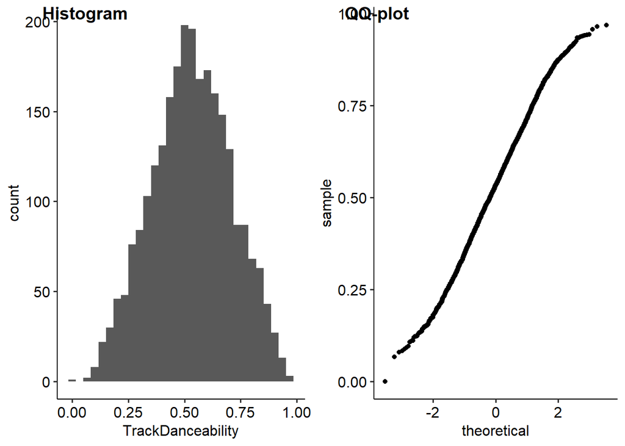

```r
h <- ggplot(data, aes(x=TrackDanceability)) + geom_histogram()
q <- ggplot(data, aes(sample=TrackDanceability))+stat_qq()
figure <- ggarrange(h,q,
                    labels = c("Histogram", "QQ-plot"),
                    ncol = 2, nrow = 1)
figure
```

**TrackEnergy**

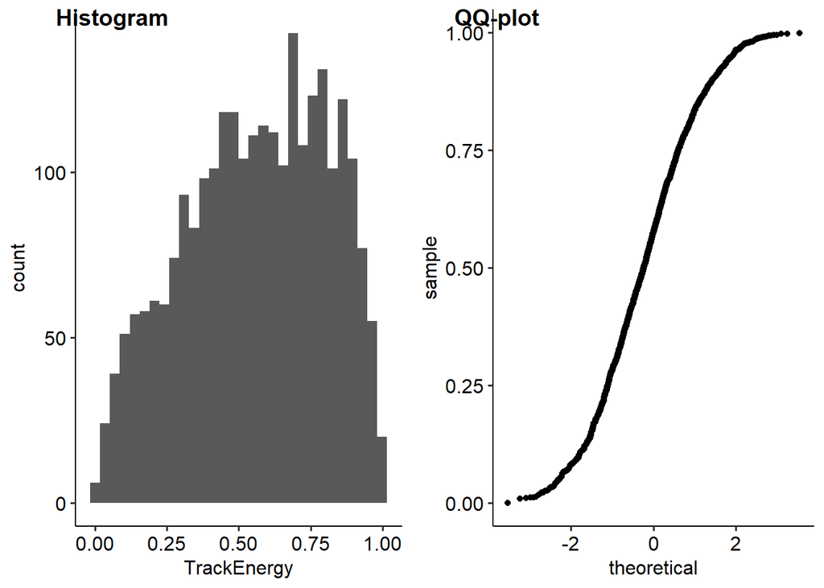

```r
h <- ggplot(data, aes(x=TrackEnergy)) + geom_histogram()
q <- ggplot(data, aes(sample=TrackEnergy))+stat_qq()
figure <- ggarrange(h,q,
                    labels = c("Histogram", "QQ-plot"),
                    ncol = 2, nrow = 1)
figure
```

**TrackLoudness**

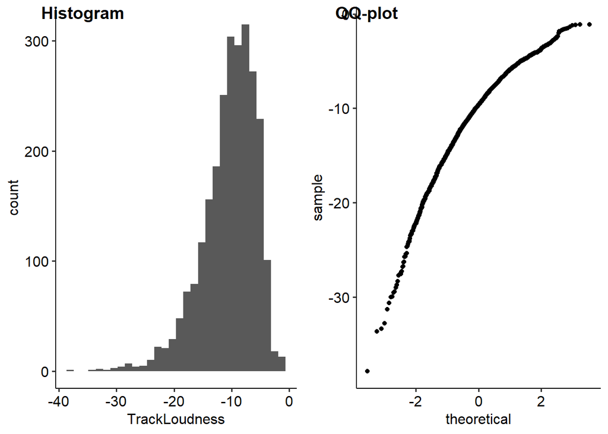

```r
h <- ggplot(data, aes(x=TrackLoudness)) + geom_histogram()
q <- ggplot(data, aes(sample=TrackLoudness))+stat_qq()
figure <- ggarrange(h,q,
                    labels = c("Histogram", "QQ-plot"),
                    ncol = 2, nrow = 1)
figure
```

**TrackSpeechiness**

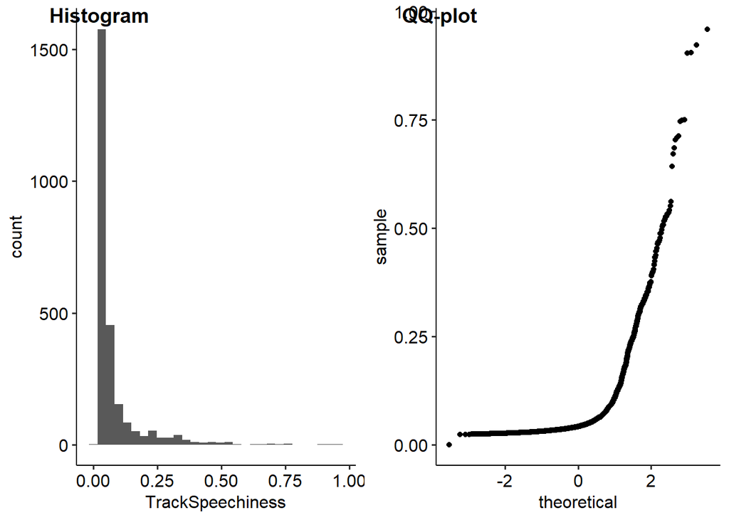

```r
h <- ggplot(data, aes(x=TrackSpeechiness)) + geom_histogram()
q <- ggplot(data, aes(sample=TrackSpeechiness))+stat_qq()
figure <- ggarrange(h,q,
                    labels = c("Histogram", "QQ-plot"),
                    ncol = 2, nrow = 1)
figure
```

**TrackAcousticness**

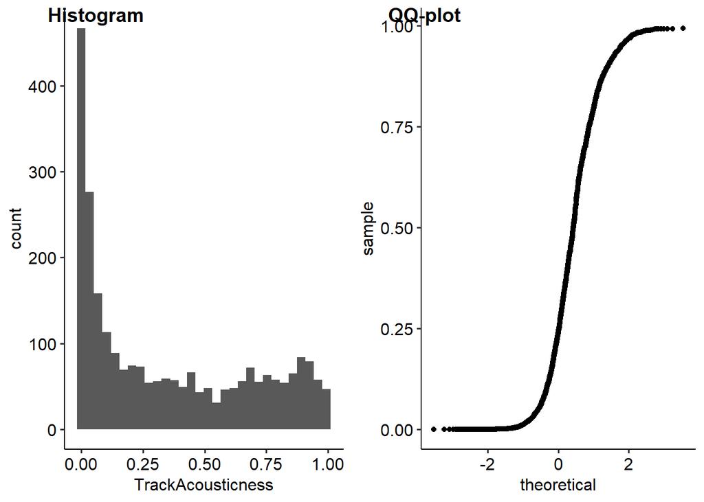

```r
h <- ggplot(data, aes(x=TrackAcousticness)) + geom_histogram()
q <- ggplot(data, aes(sample=TrackAcousticness))+stat_qq()
figure <- ggarrange(h,q,
                    labels = c("Histogram", "QQ-plot"),
                    ncol = 2, nrow = 1)
figure
```

**TrackInstrumentalness**

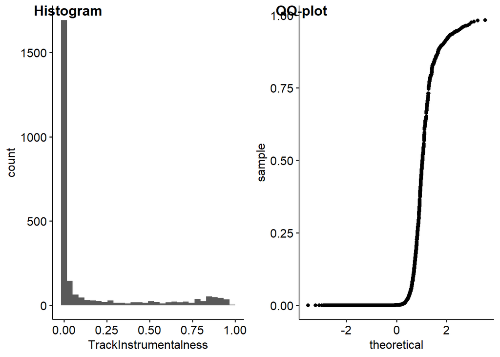

```r
h <- ggplot(data, aes(x=TrackInstrumentalness)) + geom_histogram()
q <- ggplot(data, aes(sample=TrackInstrumentalness))+stat_qq()
figure <- ggarrange(h,q,
                    labels = c("Histogram", "QQ-plot"),
                    ncol = 2, nrow = 1)
figure
```

**TrackLiveness**

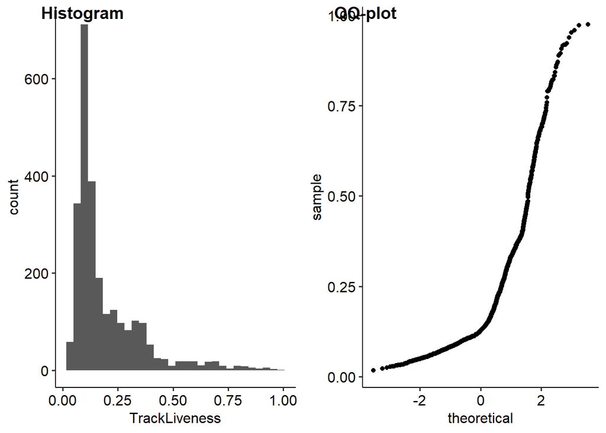

```r
h <- ggplot(data, aes(x=TrackLiveness)) + geom_histogram()
q <- ggplot(data, aes(sample=TrackLiveness))+stat_qq()
figure <- ggarrange(h,q,
                    labels = c("Histogram", "QQ-plot"),
                    ncol = 2, nrow = 1)
figure
```

**TrackValence**

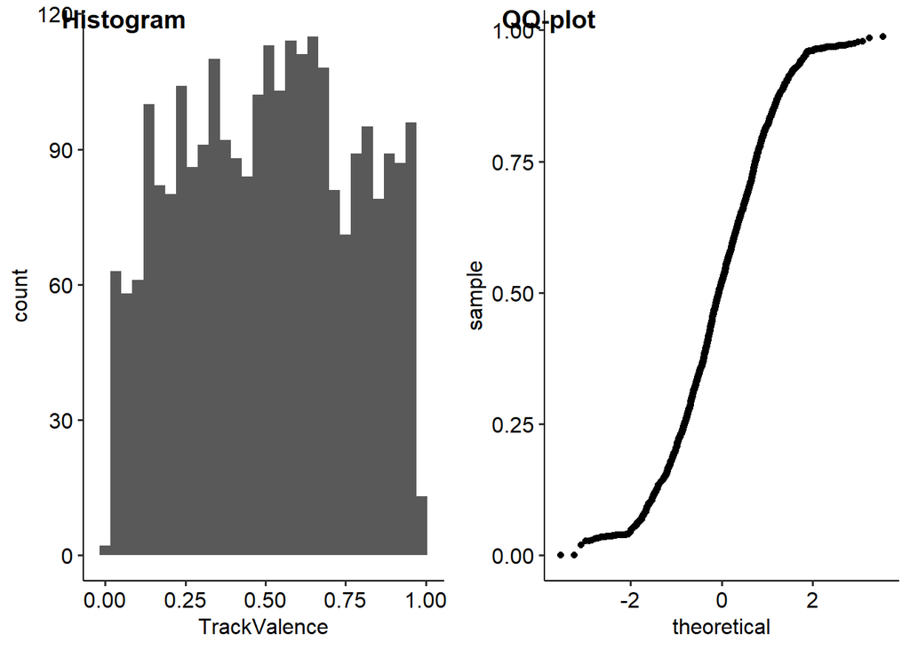

```r
h <- ggplot(data, aes(x=TrackValence)) + geom_histogram()
q <- ggplot(data, aes(sample=TrackValence))+stat_qq()
figure <- ggarrange(h,q,
                    labels = c("Histogram", "QQ-plot"),
                    ncol = 2, nrow = 1)
figure
```

**TrackTempo**

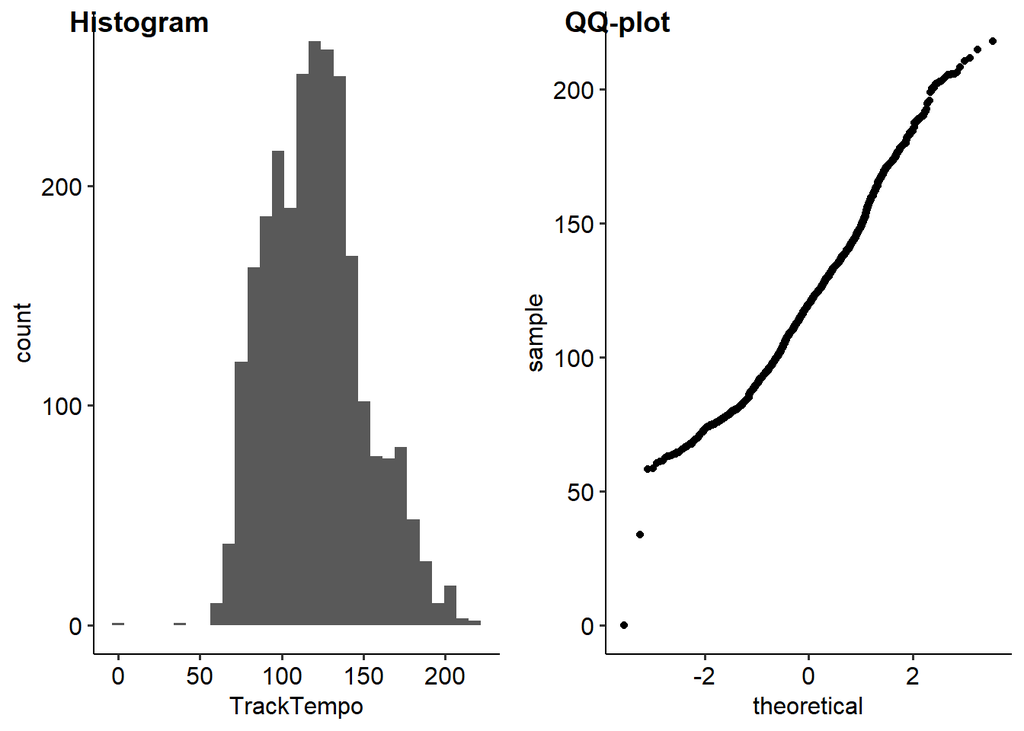

```r
h <- ggplot(data, aes(x=TrackTempo)) + geom_histogram()
q <- ggplot(data, aes(sample=TrackTempo))+stat_qq()
figure <- ggarrange(h,q,
                    labels = c("Histogram", "QQ-plot"),
                    ncol = 2, nrow = 1)
figure
```

### Read the data

```r
data <- read.csv("cleanedData.csv")
```

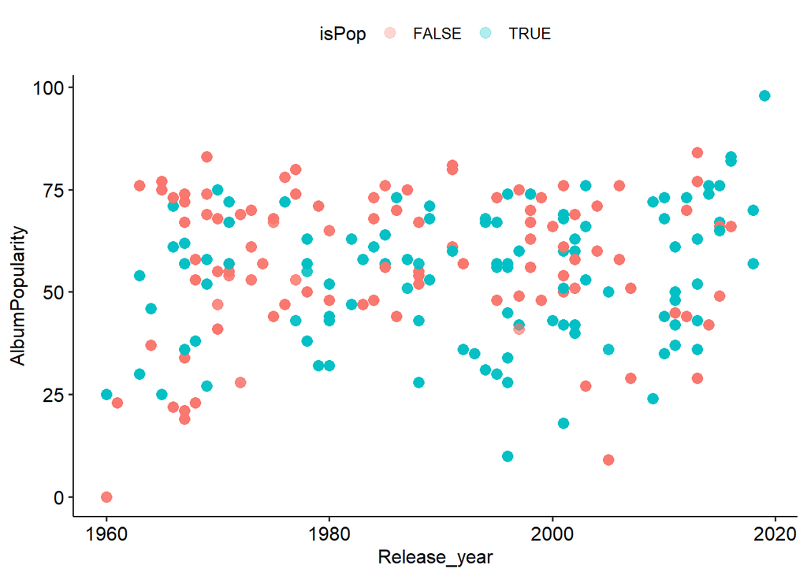

```r
ggplot(data = data, aes(x = Release_year, y = AlbumPopularity, col = isPop)) + geom_point(alpha=.3, size = 3)
```

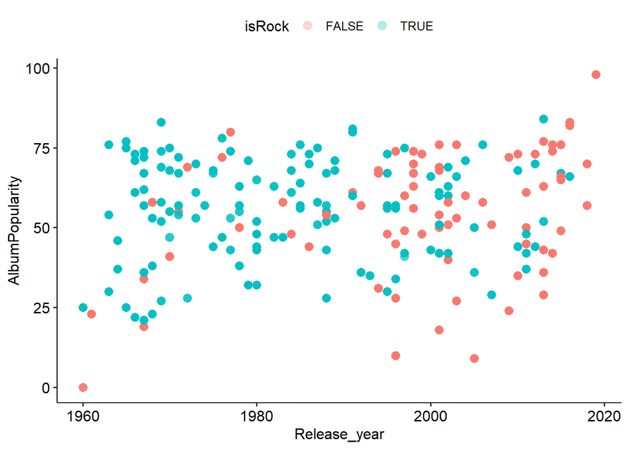

```r
ggplot(data = data, aes(x = Release_year, y = AlbumPopularity, col = isRock)) + geom_point(alpha=.3, size = 3)
```

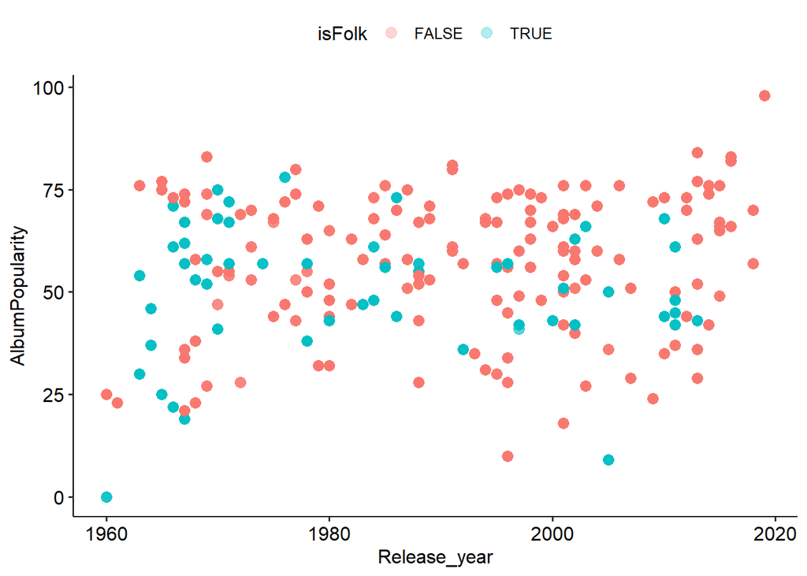

```r
ggplot(data = data, aes(x = Release_year, y = AlbumPopularity, col = isFolk)) + geom_point(alpha=.3, size = 3)
```

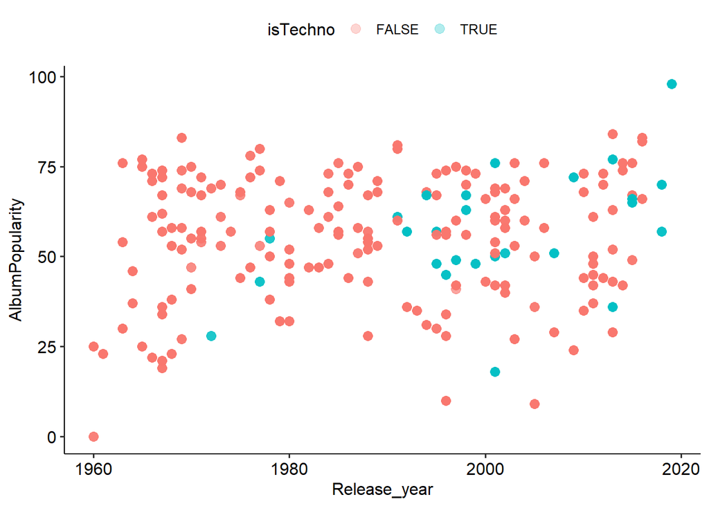

```r
ggplot(data = data, aes(x = Release_year, y = AlbumPopularity, col = isTechno)) + geom_point(alpha=.3, size = 3)
```

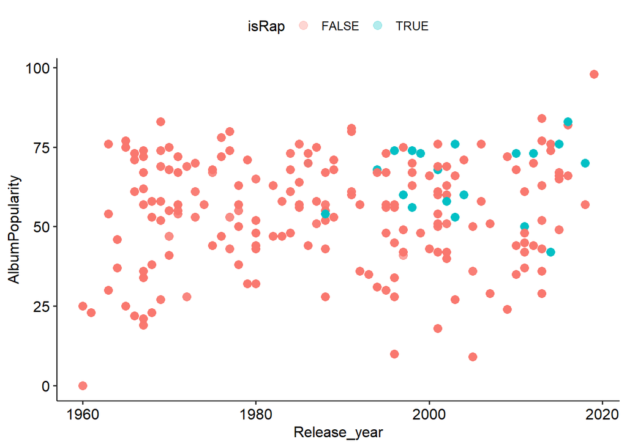

```r
ggplot(data = data, aes(x = Release_year, y = AlbumPopularity, col = isRap)) + geom_point(alpha=.3, size = 3)
```

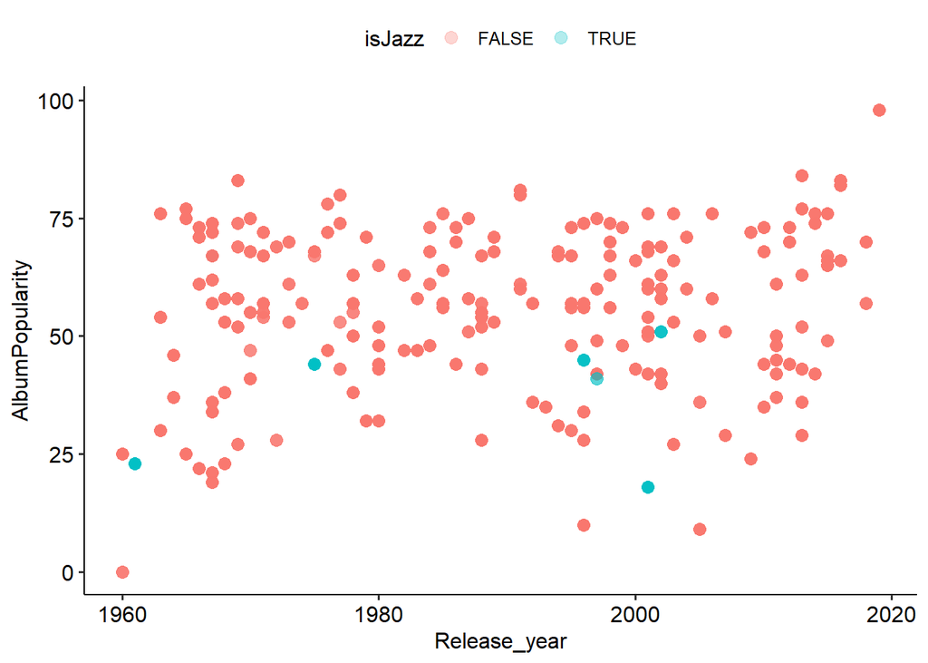

```r
ggplot(data = data, aes(x = Release_year, y = AlbumPopularity, col = isJazz)) + geom_point(alpha=.3, size = 3)
```

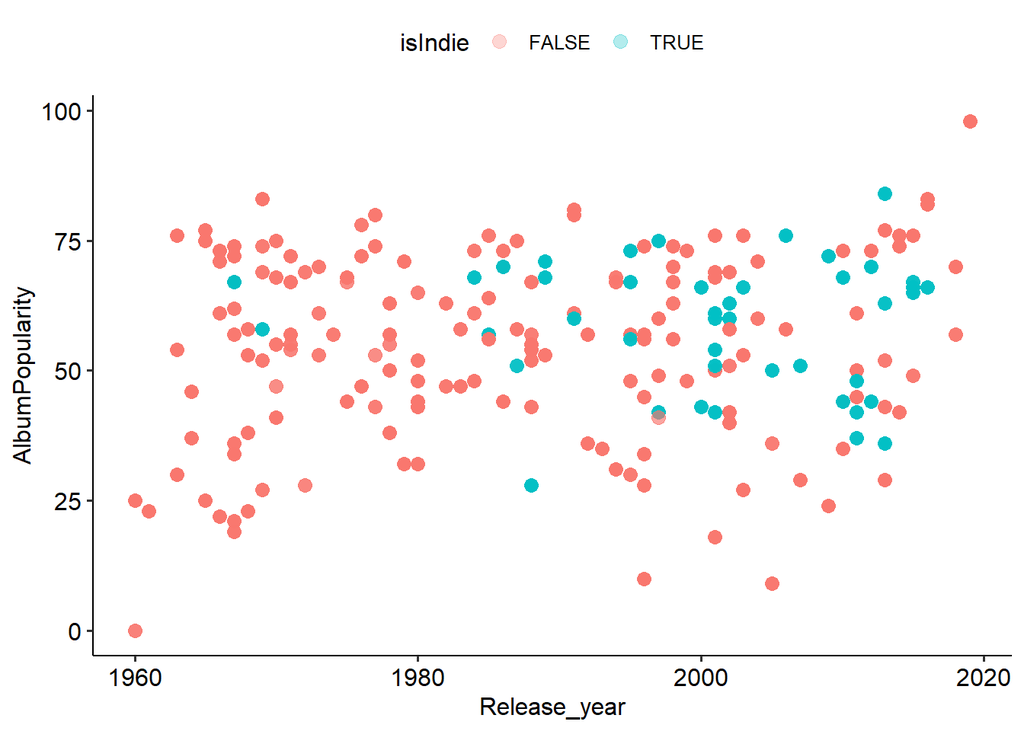

```r
ggplot(data = data, aes(x = Release_year, y = AlbumPopularity, col = isIndie)) + geom_point(alpha=.3, size = 3)
```

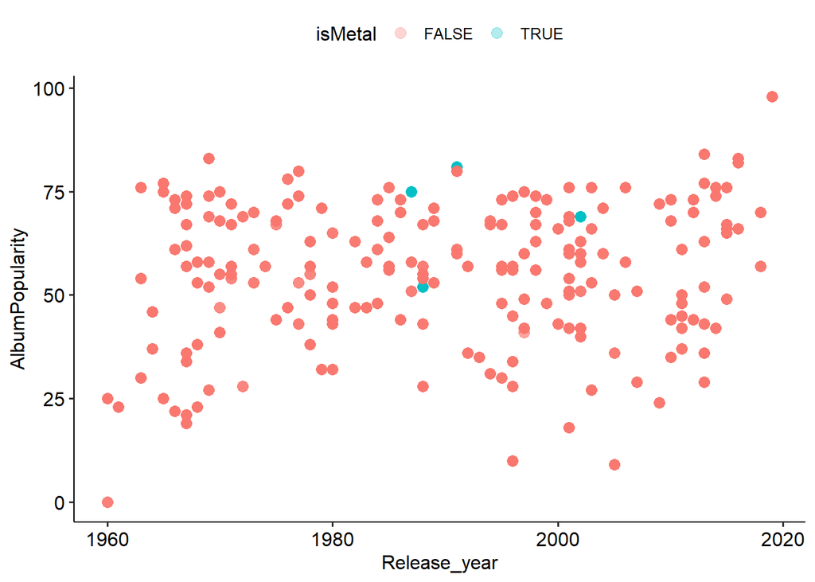

```r
ggplot(data = data, aes(x = Release_year, y = AlbumPopularity, col = isMetal)) + geom_point(alpha=.3, size = 3)
```

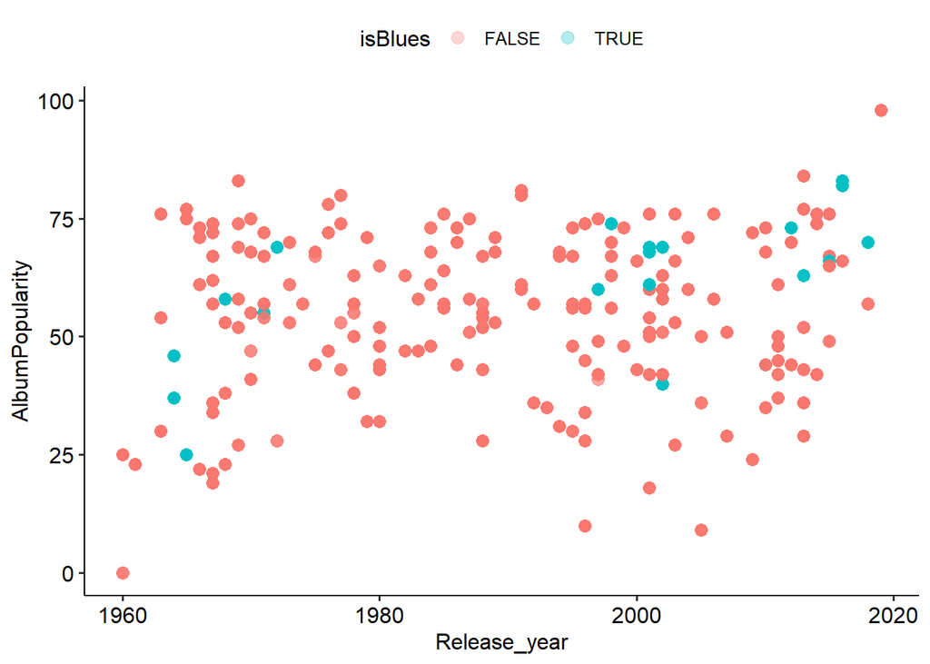

```r
ggplot(data = data, aes(x = Release_year, y = AlbumPopularity, col = isBlues)) + geom_point(alpha=.3, size = 3)
```

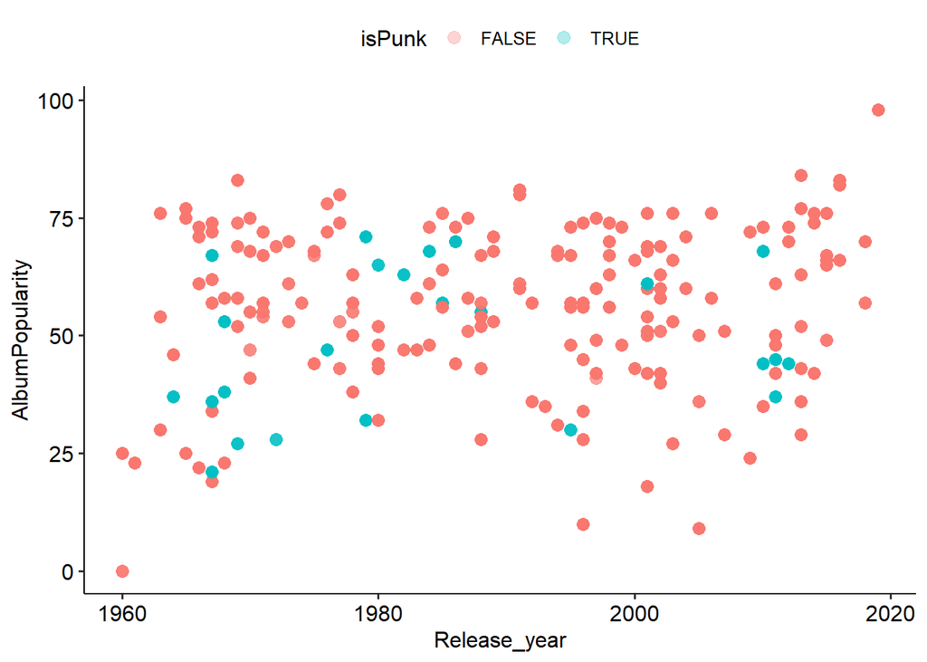

```r
ggplot(data = data, aes(x = Release_year, y = AlbumPopularity, col = isPunk)) + geom_point(alpha=.3, size = 3)
```

TESTS

### Set up

```r
data <- read.csv("cleanedData.csv")
mydata <- dplyr::select(data, ArtistID, AlbumID, TrackID, AlbumPopularity, TrackDanceability, TrackEnergy, TrackLoudness, TrackSpeechiness, TrackAcousticness, TrackInstrumentalness, TrackLiveness, TrackValence, TrackTempo)
#source("ST344-Recommendation-System.R")
```

```r
v1 <- data$TrackID[data$Artist == "Shirley Bassey" & data$AlbumName == "Shirley Bassey"]
main(as.character(sample(v1,1)))
```

```
## [1] "The Beatles : Rubber Soul : You Won't See Me"
## [1] "Simon & Garfunkel : Sounds Of Silence : Blessed"
## [1] "The Undertones : The Undertones : Wrong Way"
## [1] "The Beatles : Rubber Soul : Norwegian Wood (This Bird Has Flown)"
## [1] "The Beatles : Help! : You've Got To Hide Your Love Away"
```

```r
v2 <- data$TrackID[data$Artist == "Roy Orbison" & data$AlbumName == "In Dreams"]
main(as.character(sample(v2,1)))
```

```
## [1] "Radiohead : The Bends : Just"
## [1] "The Velvet Underground : The Velvet Underground & Nico : Run Run Run"
## [1] "The Beatles : The Beatles : Dear Prudence"
## [1] "Guns N' Roses : Appetite For Destruction : Think About You"
## [1] "The Beautiful South : Blue Is The Colour : Liars' Bar"
```

```r
v3 <- data$TrackID[data$Artist == "Pink Floyd" & data$AlbumName == "Meddle"]
main(as.character(sample(v3,1)))
```

```
## [1] "Aphex Twin : Selected Ambient Works 85-92 : Tha"
## [1] "Radiohead : A Moon Shaped Pool : Desert Island Disk"
## [1] "Nick Drake : Five Leaves Left : River Man"
## [1] "Daft Punk : Discovery : Nightvision"
## [1] "Jeremy Soule : The Elder Scrolls IV: Oblivion: Original Game Soundtrack : Fall of the Hammer"
```

```r
v4 <- data$TrackID[data$Artist == "The Clash" & data$AlbumName == "London Calling"]
main(as.character(sample(v4,1)))
```

```
## [1] "Daft Punk : Discovery : Digital Love"
## [1] "Talking Heads : Remain In Light : Crosseyed and Painless"
## [1] "Kraftwerk : Trans Europe Express : Europe Endless"
## [1] "Daft Punk : Random Access Memories : Beyond"
## [1] "Leftfield : Leftism : Afro Left"
```

```r
v5 <- data$TrackID[data$Artist == "Public Enemy" & data$AlbumName == "It Takes A Nation Of Millions To Hold Us Back"]
main(as.character(sample(v5,1)))
```

```
## [1] "Beastie Boys : Licensed To Ill : Rhymin & Stealin"
## [1] "Beastie Boys : Licensed To Ill : Girls"
## [1] "Alicia Keys : Songs In A Minor : Never Felt This Way"
## [1] "Joni Mitchell : Blue : The Last Time I Saw Richard"
## [1] "Beastie Boys : Licensed To Ill : Slow Ride"
```

```r
v6 <- data$TrackID[data$Artist == "Madness" & data$AlbumName == "Absolutely"]
main(as.character(sample(v6,1)))
```

```
## [1] "The Strokes : Is This It : Is This It"
## [1] "Prince : Purple Rain : When Doves Cry"
## [1] "Taylor Swift : 1989 : Welcome To New York"
## [1] "Manu Chao : Clandestino : Clandestino"
## [1] "The Clash : London Calling : Hateful"
```

```r
v7 <- data$TrackID[data$Artist == "Massive Attack" & data$AlbumName == "Blue Lines"]
main(as.character(sample(v7,1)))
```

```
## [1] "Garbage : Garbage : Milk"
## [1] "Leftfield : Leftism : Open Up"
## [1] "Blondie : Autoamerican : Suzy & Jeffrey"
## [1] "Portishead : Dummy : Glory Box"
## [1] "Portishead : Dummy : It's A Fire"
```

```r
v8 <- data$TrackID[data$Artist == "The Chemical Brothers" & data$AlbumName == "Dig Your Own Hole"]
main(as.character(sample(v8,1)))
```

```
## [1] "The Beatles : Revolver : Good Day Sunshine"
## [1] "Frank Ocean : Blonde : Self Control"
## [1] "Portishead : Dummy : Biscuit"
## [1] "Aretha Franklin : I Never Loved a Man the Way I Love You : Do Right Woman, Do Right Man"
## [1] "Massive Attack : Mezzanine : Man Next Door"
```

```r
v9 <- data$TrackID[data$Artist == "The Flaming Lips" & data$AlbumName == "Yoshimi Battles The Pink Robots"]
main(as.character(sample(v9,1)))
```

```
## [1] "The Proclaimers : Life With You : Calendar On The Wall"
## [1] "Arctic Monkeys : Whatever People Say I Am, That's What I'm Not : Still Take You Home"
## [1] "Underworld : Beaucoup Fish : Bruce Lee"
## [1] "The Proclaimers : Sunshine On Leith : I'm on My Way"
## [1] "Massive Attack : Mezzanine : Man Next Door"
```

```r
v10 <- data$TrackID[data$Artist == "The Streets" & data$AlbumName == "Original Pirate Material"]
main(as.character(sample(v10,1)))
```

```
## [1] "Fleetwood Mac : Rumours : Gold Dust Woman"
## [1] "Eminem : The Slim Shady LP : Rock Bottom"
## [1] "Grimes : Art Angels : Butterfly"
## [1] "Jurassic 5 : J 5 : Action Satisfaction - Dub"
## [1] "Pixies : Surfer Rosa : Brick Is Red"
```

```r
v11 <- data$TrackID[data$Artist == "Tinie Tempah" & data$AlbumName == "Disc-Overy"]
main(as.character(sample(v11,1)))
```

```
## [1] "The Beatles : Abbey Road : Here Comes The Sun"
## [1] "alt-J : An Awesome Wave : Fitzpleasure"
## [1] "The Beautiful South : Blue Is The Colour : Foundations"
## [1] "The Maccabees : Given To The Wild : Went Away"
## [1] "PJ Harvey : To Bring You My Love : Down By The Water"
```

```r
v12 <- data$TrackID[data$Artist == "Foals" & data$AlbumName == "What Went Down"]
main(as.character(sample(v12,1)))
```

```
## [1] "Massive Attack : Mezzanine : Man Next Door"
## [1] "Public Service Broadcasting : The Race For Space : The Other Side"
## [1] "The Beautiful South : Blue Is The Colour : Mirror"
## [1] "Aretha Franklin : I Never Loved a Man the Way I Love You : Dr. Feelgood (Love Is a Serious Business)"
## [1] "Wild Beasts : Smother : Reach A Bit Further"
```

**Note that the five recommended tracks are sampled based on the distribution from the selected data subset**